# 3. Main results - stunning intervention

Author

Sagar Shah, Rethink Priorities

Published

February 7, 2024

# Generic prep

Open libraries

Run code with assumptions

```r
#Useful monte carlo functions
source("0a Useful functions.R")
#Take on board assupmtions for seabream, seabass and trout
source("0b Assumptions for seabream,seabass and trout.R")
#Modelling assumptions
source("0c  Modelling assumptions.R")
```

## Helper functions

Write helper functions to call object/vectors

```r
consumption <- function(country,species)  obtain(species,country,"tons")
mshare <- function(scenario,country) obtain("mshare",scenario,country)
psuccess <- function(scenario) obtain("psuccess",scenario)
weight <- function(species) obtain("weight",species)
slaughter_minutes <- function(species) obtain("slaughter_minutes",species)
stun_share <- function(species) obtain(species,"stunned")
cost <- function(scenario) obtain("cost",scenario)
```

# Calculations

## Impact per dollar

### Core calculation function

```r
# Number of fish affected per year
no_fish_affected_per_year <- function(country,species,scenario) {
consumption(country,species)*1E3/
  weight(species)*
  (1-stun_share(species))*
  mshare(scenario,country)*
  psuccess(scenario)*
  implementation_discount*
  fish_grocery
}

# Fish affected across all years of credit
no_fish_affected <- function(country,species,scenario) {
no_fish_affected_per_year(country,species,scenario)*years_credit
}

# Fish minutes affected
fish_hours_affected <- function(country,species,scenario) {
no_fish_affected(country,species,scenario)*slaughter_minutes(species)/60
}
```

### Functions to apply calculations across countries, species and scenarios

I now produce a table that produces a possible combination of country and species

```r
no_of_countries <- length(country_list)
combo <- expand.grid(country=country_list,species=species_list) %>%
  mutate(country_species=str_c(country,"_",species))
```

I now write a function that:

- Works out the total number of fish (or fish minutes) affected in a given scenario, country and species
- Sums the result for all species and countries
- Divides by the total program costs for a specific scenario

```r
output_per_dollar <- function(fish_function,program) {

temp_output<- map2(                 # Allows repeated calcs across different input vectors
                combo$country,      # Input vector 1: countries to run function over
                combo$species,      # Input vector 2: species to run function over
                get(fish_function), # Calculation function (no of fish or minutes)
                scenario=program    # Scenario (pilot or scale)
                  ) %>%
         as.data.frame() %>%       # Convert to data.frame
         mutate(
           total=rowSums(.))

return(
  temp_output$total/(no_of_countries*cost(program))
)
}
```

Generate table for combinations of output and scenario

```r
results_combination <- expand_grid(
  measure=c("fish_hours_affected","no_fish_affected","no_fish_affected_per_year"),
  program=c("pilot","scale")) %>%
  mutate(description=str_c(program,"___",measure))
```

### Run calculations

I now write a function that works out the number of fish minutes affected and total number of fish affected per dollar across both the pilot and scale scenarios. The results of the montecarlo simulation are in a single table called “impact_per_dollar”.

```r
impact_per_dollar <- map2(                          # Function to iterate over vectors
                      results_combination$measure,  # Vector of different measures
                      results_combination$program,  # Vector of different scenarios
                      output_per_dollar) %>%        # Function to repeat
                      as.data.frame()

# Assign names to data.frame
names(impact_per_dollar) <- results_combination$description

# Convert to long format
impact_per_dollar %<>%
  pivot_longer(
    cols=1:nrow(results_combination),
    names_to="description",
    values_to="number"
) %>%
  separate_wider_delim(description,delim="___",names=c("scenario","measure"))
```

# $/DALY “welfare range” calculations

## Prep

I first produce estimates of fish years affected per dollar in both scenarios.

```r
fypd_pilot <- output_per_dollar("fish_hours_affected","pilot")*hours_to_years
fypd_scale <- output_per_dollar("fish_hours_affected","scale")*hours_to_years
fypd <- function(scenario) obtain("fypd",scenario)
```

## Core calculation functions

```r
wr_dollar_per_daly <- function(scenario) {
   1/(
    fypd(scenario)*
    salmon_wr*
    duration_share*
    fish_welfarerange_impact_stun/
    DALY_share_of_welfare_range)
}
```

## Apply calculations

Calculate results and place into data frame

```r
results_dollar_per_daly <-
tibble(
          # core calculations
  pilot=wr_dollar_per_daly("pilot"),
  scale=wr_dollar_per_daly("scale")) %>%
          # pivot to long format
  pivot_longer(
    cols=1:2,
    values_to="dollars_per_daly",
    names_to="scenario"
  ) %>%
          # reformat for table production
  mutate(scenario=str_to_sentence(scenario))
```

# Share of simulations beating $/DALY benchmark

## Core calculation functions

```r
#Moral value approach
share_mv <- function(xvar,scenario,bar) {
  mean(bar>(1/(fypd(scenario)*xvar)))
}

# Welfare range approach
share_wr <- function(xvar,scenario,bar) {
  mean(bar>
      (1/
        (xvar*
        fypd(scenario)*
        salmon_wr/
        DALY_share_of_welfare_range
        )))
}
```

Define parameters over which to calculate results. Definition of xvar provided in the table below.

| Approach | Meaning of ‘xvar’ variable means in context of calculations |
| --- | --- |
| Moral Value | Moral value of improving fish welfare for 1 year through intervention relative to gaining 1 DALY |
| Welfare Range | Welfare gain from intervention **-** expressed as % of entire fish welfare range (negative to positive) |

## Assign values over which calculations are performed

```r
  mv_table_values <- c(0.01,0.1,0.25,0.5,0.75,1,5,10,25,50,75,100,500,1000,5000)
  wr_table_values <- c(0.01,0.05,0.1,0.25,0.5,0.75,0.9,0.95,0.99,1)
  chart_values<- 10^seq(-4,4,0.01)
  xvar_values <- c(chart_values,mv_table_values,wr_table_values)
  scenario_list <- c("pilot","scale")
```

## Run calculations

```r
share_sims_results_table <-
# Generate one row for unique combination of xvar_values and scenario lists
  expand_grid(
    xvar=xvar_values,
    scenario=scenario_list,
    bar=bar_values) %>%
# Core calcualtions using share_mv and share_wr calculation functions
    rowwise() %>%
    mutate(
      moral_value=share_mv(xvar,scenario,bar),
      welfare_range=share_wr(xvar,scenario,bar)
    ) %>%
# Convert pivot into longer format to make results easier to plot
  pivot_longer(
    cols=c(moral_value,welfare_range),
    names_to="approach",
    values_to="share_of_simulations") %>%
# Change descriptions of variables to make results easier to interpert
  mutate(
    scenario=str_to_sentence(scenario),
    approach=str_to_sentence(str_replace_all(approach,"_"," ")),
    bar_factor=
      factor(bar,levels=bar_values,labels=c("50","1K","70K")),
    bar_description=case_when(
      bar==50 ~ "50 - Open Philanthropy GHW bar",
      bar==1000 ~ "1K - Low HDI country HE av.",
      bar==70000 ~ "70K - Very high HDI country HE av.",
      TRUE ~ "ERROR")
  )
```

# Produce results tables/charts

## Impact per dollar

```r
# Code to create impact per dollar density plot

impact_density_plot <- function(desired_filter,description) {
  impact_per_dollar %>%
  filter(measure==desired_filter) %>%
  ggplot(
    aes(
      x=number,
      color=str_to_sentence(scenario)
    )
  ) +
  geom_density() +
  theme_light() +
  scale_x_log10(labels = scales::comma_format(drop0trailing = TRUE),n.breaks=8) +
    labs(
    title=description,
    y="Probability density",
    x=paste0(description," (log scale)"),
    color="Scenario")
}

# Code to create impact per dollar summary table

impact_table <- function(desired_filter,description) {
impact_per_dollar %>%
  filter(measure==desired_filter) %>%
  mutate(scenario=str_to_sentence(scenario)) %>%
  group_by(scenario) %>%
  summarise(
    Mean=mean(number),
    p5=quantile(number,0.05),
    Median=median(number),
    p95=quantile(number,0.95)
  ) %>%
  pivot_longer(cols=2:5,names_to="Statistic",values_to="Value") %>%
  pivot_wider(names_from = "scenario",values_from = "Value") %>%
  gt() %>%
  fmt_number(decimals = 1) %>%
  tab_header(
  title = description) %>%
  tab_spanner(
    label = "Scenario",
    columns = c(Pilot,Scale))
}

# Generate results

fig9_fish_pd <- impact_density_plot("no_fish_affected","Number of fish affected per dollar")
tab8_fish_pd<- impact_table("no_fish_affected","Number of fish affected per dollar")
tab9_fish_pdpy <- impact_table("no_fish_affected_per_year","Number of fish affected per dollar per year")
fig10_fish_hours_pd <- impact_density_plot("fish_hours_affected","Fish hours affected per dollar")
tab10_fish_hours_pd <- impact_table("fish_hours_affected","Fish hours affected per dollar")
```

## $/DALY Range

Density plot

```r
fig11_dolperdaly_density <-
  results_dollar_per_daly %>%
  ggplot(
    aes(
      x=dollars_per_daly,
      color=scenario
    )
  ) +
  geom_density() +
  theme_light() +
  scale_x_log10(
    breaks=10^seq(0,15,1),
    labels = scales::label_number(scale_cut = scales::cut_short_scale())) +
    labs(
    title = "$/DALY Density Plot",
    y="Probability density",
    x="$/DALY (log-scale)",
    color="Scenario")
```

Summary stats table

```r
tab11_dolperdaly_density <-
results_dollar_per_daly %>%
  group_by(scenario) %>%
  summarise(
    Mean=mean(dollars_per_daly),
    p1=quantile(dollars_per_daly,0.01),
    p5=quantile(dollars_per_daly,0.05),
    p10=quantile(dollars_per_daly,0.10),
    p25=quantile(dollars_per_daly,0.25),
    Median=median(dollars_per_daly),
    p75=quantile(dollars_per_daly,0.75),
    p90=quantile(dollars_per_daly,0.90),
    p95=quantile(dollars_per_daly,0.95),
    p99=quantile(dollars_per_daly,0.99)
  ) %>%
  pivot_longer(cols=2:11,names_to="Statistic",values_to="$/DALY") %>%
  pivot_wider(names_from = "scenario",values_from = "$/DALY") %>%
  gt() %>%
  tab_spanner(
    label = "Scenario",
    columns = c(Pilot,Scale)) %>%
  fmt_number(columns=2:3,suffixing=TRUE,n_sigfig =3)
```

## Share of simulations beating benchmark

### Chart code function

```r
share_sims_chart <- function (
                        chart_approach,
                        xvar_lower_lim=0,
                        xvar_upper_lim=max(xvar_values),
                        xlab_des
                        ) {

share_sims_results_table %>%
    filter(
    approach==chart_approach,
    xvar<=xvar_upper_lim,
    xvar>=xvar_lower_lim
    ) %>%
  ggplot(
    aes(
      x=xvar,
      y=share_of_simulations,
      color=as.factor(scenario),
      linetype=bar_factor))+
  geom_line(lwd=0.8)+
  scale_linetype_manual(values=c("solid","dotted","twodash"))+
  scale_color_brewer(palette = "Dark2")+
  theme_light()+
  scale_y_continuous(limits=c(0,1),n.breaks=10,labels = scales::percent_format(accuracy = 1))+
  labs(
    subtitle = str_to_title(paste0(chart_approach," approach")),
    title="Share of simulations where intervention beats $/DALY benchmark",
    y="Share of simulations",
    x=xlab_des,
    linetype="$/DALY Benchmark",
    color="Intervention",
    caption= "Note log scale on x-axis")

}


xlab_wr="
    Welfare gain from intervention as a % of total fish welfare range"

xlab_mv="Moral value of improving a fish-life year via intervention
relative to gaining a human DALY"
```

### Produce charts

```r
fig12_wr_benchmark <-share_sims_chart("Welfare range",xvar_upper_lim=1,xlab_des=xlab_wr)+
  scale_x_log10(limits=c(0.001,1),labels = scales::percent_format(drop0trailing = TRUE),n.breaks=10)+
  scale_y_continuous(limits=c(0,0.6),n.breaks=10,labels = scales::percent_format(accuracy = 1))

fig13_mv_benchmark <- share_sims_chart("Moral value",xvar_lower_lim=0.003,xlab_des=xlab_mv)+
  scale_x_log10(labels = scales::label_number_si(drop0trailing = TRUE),n.breaks=11)
```

### Table function

Share of simulations at various welfare range / moral value assumptions.

```r
share_beating_bar_table <- function(values,chart_approach) {
share_sims_results_table %>%
  filter(
      xvar %in% values,
      approach==chart_approach) %>%
  select(-approach) %>%
  distinct() %>%
  mutate(
    scenario_bar=paste(scenario,bar,sep="_")) %>%
  pivot_wider(id_cols=xvar,names_from=scenario_bar,values_from=share_of_simulations) %>%
  arrange(xvar) %>%
  gt() %>%
  tab_header(title = "Share of simulations beating $DALY bar") %>%
  cols_label(xvar=chart_approach)
}
```

### Produce tables

```r
tab12_wr_benchmark <- share_beating_bar_table(wr_table_values,"Welfare range") %>%
    fmt_percent(columns=1,decimals=0) %>%
    fmt_percent(columns=2:7,decimals=1)


tab13_mv_benchmark <- share_beating_bar_table(mv_table_values,"Moral value") %>%
  fmt_percent(columns=2:7,decimals=1)
```

### Minimum moral value table

Minimum moral value needed to achieve given share of simulations to beat $/DALY bar.

```r
sim_cuts<- c(0,0.01,0.1,0.25,0.5,0.75,0.90,0.95,0.99,1,1.01)

tab14_min_mv <- share_sims_results_table %>%
filter(approach=="Moral value") %>%
  mutate(
    sims_bin=
      cut(share_of_simulations,breaks=sim_cuts,right=FALSE,labels=head(sim_cuts,-1))) %>%
  group_by(scenario,bar,sims_bin) %>%
  summarise(min_moral_value=min(xvar)) %>%
  mutate(scenario_bar=str_c(scenario,bar,sep="_")) %>%
  pivot_wider(id_cols=sims_bin,names_from=scenario_bar,values_from=min_moral_value) %>%
  mutate(sims_bin=head(sim_cuts,-1)) %>%
  gt() %>%
  fmt_percent(columns=1,decimals=0) %>%
  fmt_number(columns=2:7,decimals=1) %>%
  tab_header(title = "Minimum moral value assumption needed for to achieve share of simulations beating bar")
```

# Print charts and tables

Impact per dollar charts and tables

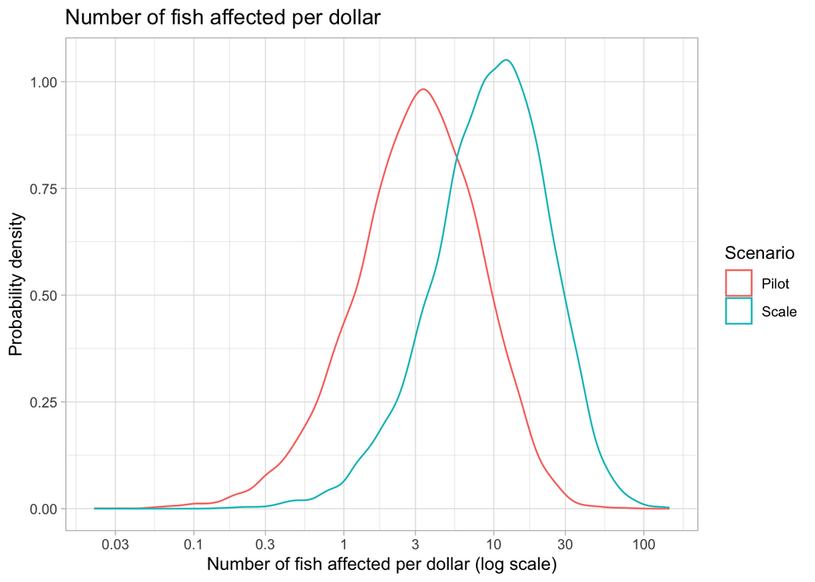

```r
fig9_fish_pd
```

```r
tab8_fish_pd
```

Number of fish affected per dollar

| Statistic | Scenario Pilot | Scenario Scale |
| --- | --- | --- |
| Mean | 4.6 | 13.3 |
| p5 | 0.6 | 1.9 |
| Median | 3.2 | 9.9 |
| p95 | 13.5 | 36.0 |

```r
tab9_fish_pdpy
```

Number of fish affected per dollar per year

| Statistic | Scenario Pilot | Scenario Scale |
| --- | --- | --- |
| Mean | 0.4 | 1.2 |
| p5 | 0.1 | 0.2 |
| Median | 0.3 | 1.0 |
| p95 | 1.1 | 2.8 |

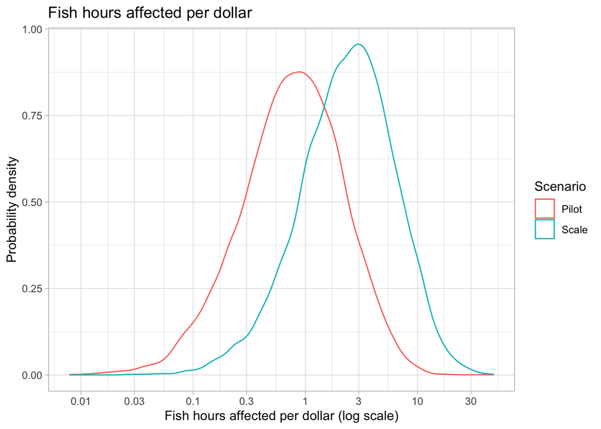

```r
fig10_fish_hours_pd
```

```r
tab10_fish_hours_pd
```

Fish hours affected per dollar

| Statistic | Scenario Pilot | Scenario Scale |
| --- | --- | --- |
| Mean | 1.2 | 3.6 |
| p5 | 0.1 | 0.4 |
| Median | 0.8 | 2.5 |
| p95 | 3.8 | 10.4 |

Dollar per daly distribution

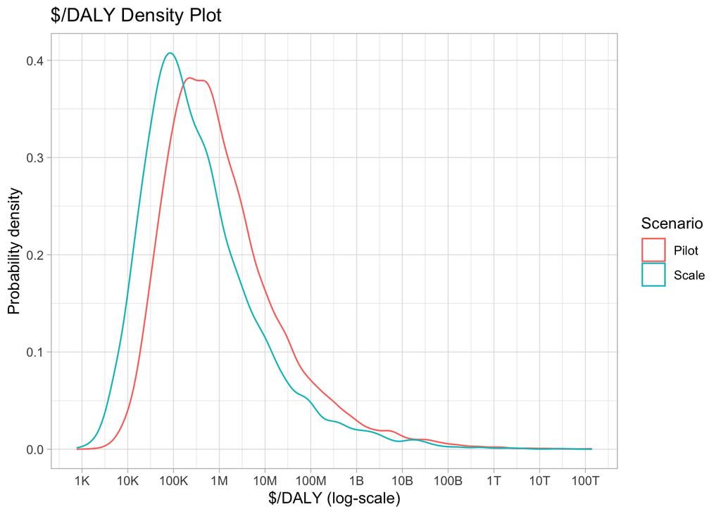

```r
fig11_dolperdaly_density
```

```r
tab11_dolperdaly_density
```

| Statistic | Scenario Pilot | Scenario Scale |
| --- | --- | --- |
| Mean | 41.1B | 12.3B |
| p1 | 11.8K | 4.11K |
| p5 | 29.9K | 10.4K |
| p10 | 52.3K | 17.8K |
| p25 | 151K | 51.0K |
| Median | 680K | 216K |
| p75 | 4.92M | 1.61M |
| p90 | 61.0M | 18.1M |
| p95 | 366M | 114M |
| p99 | 26.9B | 9.98B |

Welfare range benchmarks

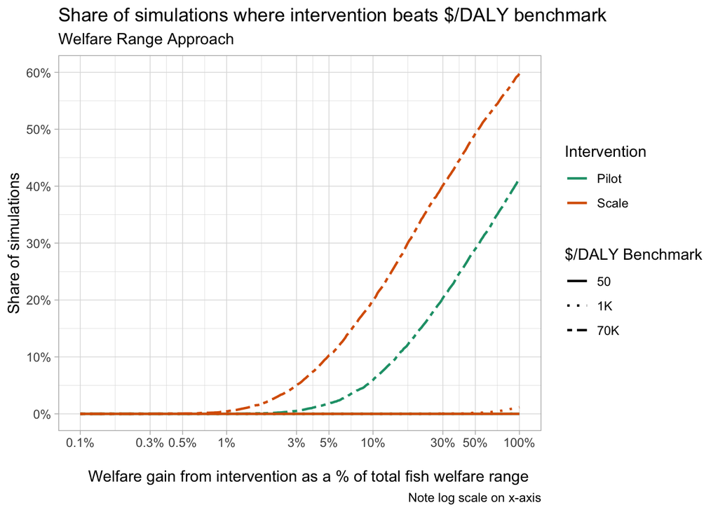

```r
fig12_wr_benchmark
```

```r
tab12_wr_benchmark
```

Share of simulations beating $DALY bar

| Welfare range | Pilot_50 | Pilot_1000 | Pilot_70000 | Scale_50 | Scale_1000 | Scale_70000 |
| --- | --- | --- | --- | --- | --- | --- |
| 1% | 0.0% | 0.0% | 0.0% | 0.0% | 0.0% | 0.4% |
| 5% | 0.0% | 0.0% | 1.8% | 0.0% | 0.0% | 10.3% |
| 10% | 0.0% | 0.0% | 5.9% | 0.0% | 0.0% | 20.0% |
| 25% | 0.0% | 0.0% | 17.5% | 0.0% | 0.0% | 37.0% |
| 50% | 0.0% | 0.0% | 29.0% | 0.0% | 0.2% | 49.2% |
| 75% | 0.0% | 0.0% | 36.1% | 0.0% | 0.5% | 55.5% |
| 90% | 0.0% | 0.0% | 39.4% | 0.0% | 0.9% | 58.2% |
| 95% | 0.0% | 0.0% | 40.4% | 0.0% | 1.0% | 59.1% |
| 99% | 0.0% | 0.0% | 41.2% | 0.0% | 1.1% | 59.6% |
| 100% | 0.0% | 0.0% | 41.4% | 0.0% | 1.2% | 59.8% |

Moral value benchmarks

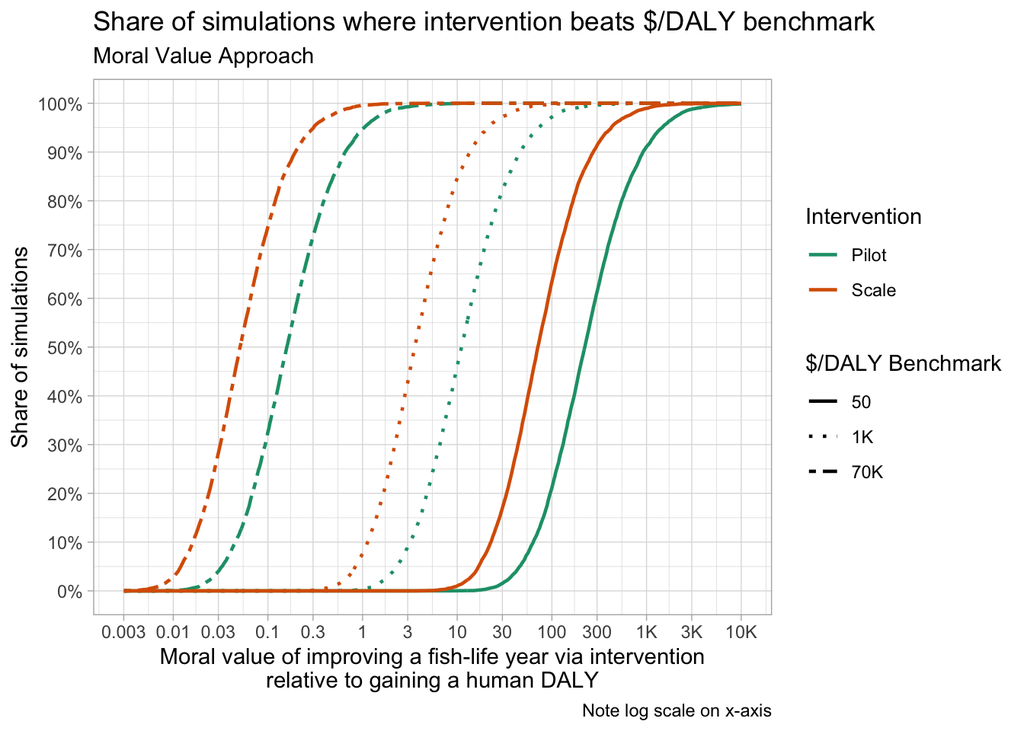

```r
fig13_mv_benchmark
```

```r
tab13_mv_benchmark
```

Share of simulations beating $DALY bar

| Moral value | Pilot_50 | Pilot_1000 | Pilot_70000 | Scale_50 | Scale_1000 | Scale_70000 |
| --- | --- | --- | --- | --- | --- | --- |
| 0.01 | 0.0% | 0.0% | 0.1% | 0.0% | 0.0% | 2.9% |
| 0.10 | 0.0% | 0.0% | 32.6% | 0.0% | 0.0% | 74.7% |
| 0.25 | 0.0% | 0.0% | 66.8% | 0.0% | 0.1% | 93.3% |
| 0.50 | 0.0% | 0.0% | 85.3% | 0.0% | 1.0% | 97.8% |
| 0.75 | 0.0% | 0.1% | 91.5% | 0.0% | 3.5% | 99.0% |
| 1.00 | 0.0% | 0.4% | 94.7% | 0.0% | 7.6% | 99.6% |
| 5.00 | 0.0% | 21.1% | 99.7% | 0.1% | 63.4% | 100.0% |
| 10.00 | 0.0% | 46.1% | 100.0% | 1.0% | 84.6% | 100.0% |
| 25.00 | 0.8% | 77.7% | 100.0% | 12.2% | 96.3% | 100.0% |
| 50.00 | 6.1% | 91.1% | 100.0% | 35.3% | 98.9% | 100.0% |
| 75.00 | 13.2% | 95.3% | 100.0% | 52.1% | 99.6% | 100.0% |
| 100.00 | 21.1% | 97.2% | 100.0% | 63.4% | 99.8% | 100.0% |
| 500.00 | 77.7% | 99.9% | 100.0% | 96.3% | 100.0% | 100.0% |
| 1000.00 | 91.1% | 100.0% | 100.0% | 98.9% | 100.0% | 100.0% |
| 5000.00 | 99.5% | 100.0% | 100.0% | 100.0% | 100.0% | 100.0% |

```r
tab14_min_mv
```

Minimum moral value assumption needed for to achieve share of simulations beating bar

| sims_bin | Pilot_50 | Pilot_1000 | Pilot_70000 | Scale_50 | Scale_1000 | Scale_70000 |
| --- | --- | --- | --- | --- | --- | --- |
| 0% | 0.0 | 0.0 | 0.0 | 0.0 | 0.0 | 0.0 |
| 1% | 26.9 | 1.3 | 0.0 | 10.0 | 0.5 | 0.0 |
| 10% | 64.6 | 3.2 | 0.0 | 22.9 | 1.1 | 0.0 |
| 25% | 114.8 | 5.6 | 0.1 | 38.9 | 1.9 | 0.0 |
| 50% | 223.9 | 11.2 | 0.2 | 72.4 | 3.6 | 0.1 |
| 75% | 457.1 | 22.9 | 0.3 | 144.5 | 7.1 | 0.1 |
| 90% | 933.3 | 46.8 | 0.7 | 275.4 | 13.8 | 0.2 |
| 95% | 1,479.1 | 74.1 | 1.0 | 426.6 | 21.4 | 0.3 |
| 99% | 3,467.4 | 173.8 | 2.5 | 1,023.3 | 51.3 | 0.7 |
| 100% | NA | 1,122.0 | 16.2 | 6,456.5 | 323.6 | 4.7 |

# Export charts and tables

```r
save_chart("fig9_fish_pd.png",fig9_fish_pd)
save_chart("fig10_fish_hours_pd.png",fig10_fish_hours_pd)
save_chart("fig11_dolperdaly_density.png",fig11_dolperdaly_density)
save_chart("fig12_wr_benchmark.png",fig12_wr_benchmark)
save_chart("fig13_mv_benchmark.png",fig13_mv_benchmark)
save_chart("fig13_mv_benchmark.png",fig13_mv_benchmark)



save_table(tab8_fish_pd,"tab8_fish_pd.html")
save_table(tab9_fish_pdpy,"tab9_fish_pdpy.html")
save_table(tab10_fish_hours_pd,"tab10_fish_hours_pd.html")
save_table(tab11_dolperdaly_density,"tab11_dolperdaly_density.html")
save_table(tab12_wr_benchmark,"tab12_wr_benchmark.html")
save_table(tab13_mv_benchmark ,"tab13_mv_benchmark.html")
save_table(tab14_min_mv,"tab14_min_mv.html")
```

```r
saveRDS(fypd_scale,file= "../3_intermediate_data/fypd_scale.rds")
```

# Additional analyses

## Sensitivity to DALY as a share of human welfare range assumption

This section examines how the share of simulations beating various benchmarks under an assumption that an intervention that improves welfare by 10% of the human welfare range for a year is equivalent to averting a DALY, rather than 50%.

Calculation function

```r
share_wr_alt <- function(xvar,scenario,bar) {
  mean(bar>
      (1/
        (xvar*
        fypd(scenario)*
        salmon_wr_alt/
        DALY_share_of_welfare_range_alt
        )))
}
```

Generate output table

```r
# Generate one row for unique combination of xvar_values and scenario lists

alt_output_table <- expand_grid(
    xvar=wr_table_values,
    scenario="scale",
    bar=bar_values) %>%
# Core calcualtions using share_mv and share_wr calculation functions
    rowwise() %>%
    mutate(
      base=share_wr(xvar,scenario,bar),
      alt=share_wr_alt(xvar,scenario,bar)
    ) %>%
   select(-scenario) %>%
   pivot_longer(
     cols=c(base,alt),
     names_to="wr_assumptions",
     values_to="share_of_sims") %>%
  mutate(
      bar_factor=
      factor(bar,levels=bar_values,labels=c("50","1K","70K"))) %>%
  pivot_wider(
    id_cols=xvar,
    names_from=c(wr_assumptions,bar_factor),
    values_from=share_of_sims) %>%
  gt() %>%
  fmt_percent(decimals =1) %>%
  fmt_percent(columns=xvar,decimals =0) %>%
    cols_label(
    xvar = "Welfare range impact")
```

Output table is printed below. Overall conclusions do not appear overly sensitive to this assumption. If the stunning intervention improves fish welfare by an average 50% of the fish welfare range for the entire (non-stunning) slaughter duration, it will beat a benchmark of $1K/DALY in only 14.9% of simulations.

```r
alt_output_table
```

| Welfare range impact | base_50 | alt_50 | base_1K | alt_1K | base_70K | alt_70K |
| --- | --- | --- | --- | --- | --- | --- |
| 1% | 0.0% | 0.0% | 0.0% | 0.0% | 0.4% | 20.0% |
| 5% | 0.0% | 0.0% | 0.0% | 0.2% | 10.3% | 49.2% |
| 10% | 0.0% | 0.0% | 0.0% | 1.2% | 20.0% | 59.8% |
| 25% | 0.0% | 0.0% | 0.0% | 6.6% | 37.0% | 71.1% |
| 50% | 0.0% | 0.0% | 0.2% | 14.9% | 49.2% | 77.3% |
| 75% | 0.0% | 0.1% | 0.5% | 21.2% | 55.5% | 80.6% |
| 90% | 0.0% | 0.1% | 0.9% | 24.2% | 58.2% | 82.0% |
| 95% | 0.0% | 0.2% | 1.0% | 25.2% | 59.1% | 82.3% |
| 99% | 0.0% | 0.2% | 1.1% | 26.0% | 59.6% | 82.5% |
| 100% | 0.0% | 0.2% | 1.2% | 26.2% | 59.8% | 82.5% |

## How might animals affected per dollar from the fish stunning intervention compare to marginal chicken grants

I this section I perform a quick BOTEC to see how the animals affected per dollar from the fish stunning intervention in the scale scenario might compare to marginal chicken grants.

I first import raw sample data (5000 simulations) for chickens affected per dollar from the Guesstimate model from Šimčikas (2019).

```r
# Import data on chickens affected per dollar from Guesstimate samples
chickens_per_dollar_historic <-
  read_csv("../1_input_data/chickens_per_dollar.csv",show_col_types=FALSE) %>%
  pull(chickens_per_dollar) %>%
  sample(sims,replace=TRUE)
```

I then estimate marginal chickens affected per dollar, conditional on an assumption that marginal grants may impact 3.5 to 5 times fewer animals per dollar (uniform distribution), than historic ones.

```r
# Assumption about guesstimate samples
decrease_in_chicken_effectiveness <- runi(3.5,5)
chickens_per_dollar_marginal <- chickens_per_dollar_historic/decrease_in_chicken_effectiveness
```

I then work out the share of simulations where marginal chicken grants affect more animals per dollar then fish stunning grants in the scale scenario (about half the time)

```r
# Assumption about guesstimate samples
mean(chickens_per_dollar_marginal>output_per_dollar("no_fish_affected","scale"))
```

```
[1] 0.4948
```

I then look at how the overall distributions compare (look comparable)

```r
summarystats(chickens_per_dollar_marginal,output_per_dollar("no_fish_affected","scale"))
```

| statistic | chickens_per_dollar_marginal | output_per_dollar("no_fish_affected", "scale") |
| --- | --- | --- |
| mean | 14.9 | 13.3 |
| sd | 17.5 | 11.8 |
| median | 9.08 | 9.90 |
| p5 | 2.14 | 1.89 |
| p10 | 2.92 | 2.89 |
| p25 | 4.95 | 5.37 |
| p75 | 18.0 | 17.4 |
| p90 | 33.3 | 27.9 |
| p95 | 47.4 | 36.0 |